# FDA Drug Adverse Events - Data Exploration

rstudio February 10, 2020

#’

### How many Records per day?

- **Just for this section, let’s keep the timeframe to Jan 2017 to 2019 Q3**
- There is an API that returns a timeseries - let’s use it
- Ref: https://open.fda.gov/apis/timeseries/

```
## [1] "2017-01-01" "2019-09-30"
```

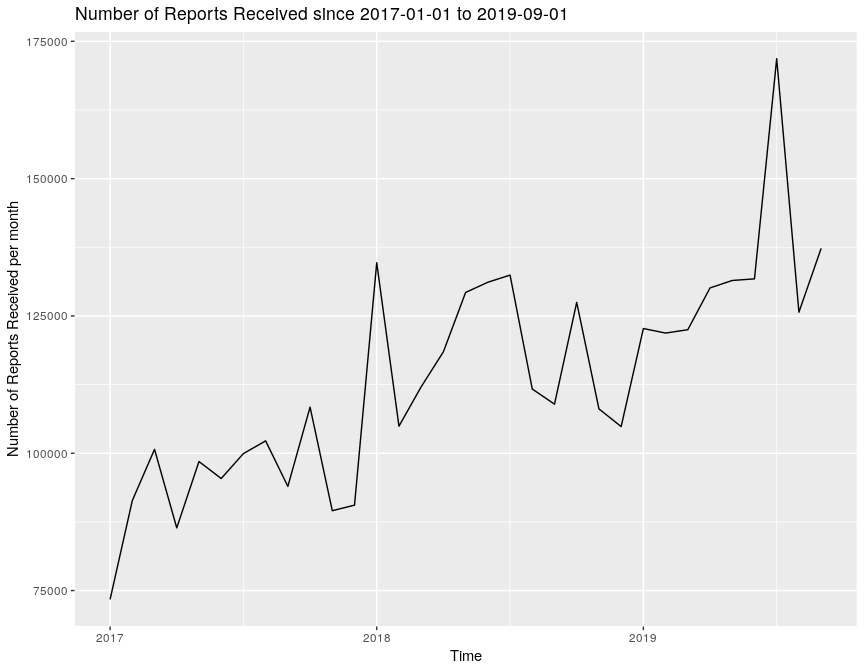

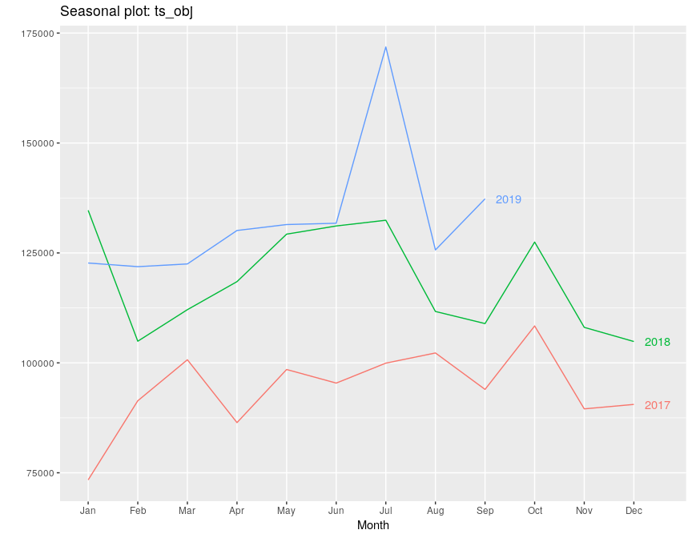

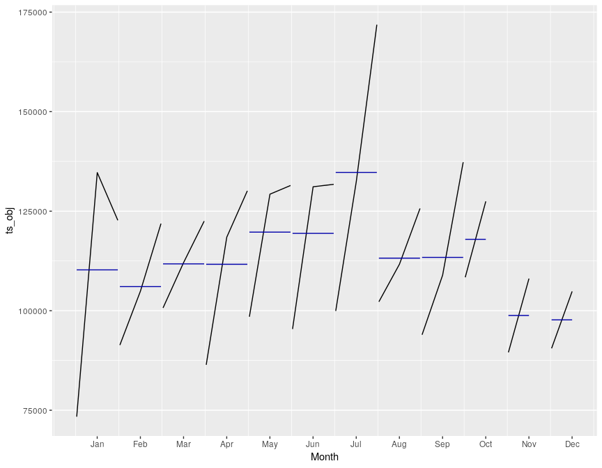

### Explore 2019 Q3 data

- **This analysis is primarily restricted to events within 2019 Q3.**

```
## Observations: 441,477
## Variables: 39
## $ receivedate                              <chr> "20190408", "20190408",…
## $ receivedateformat                        <chr> "102", "102", "102", "1…
## $ transmissiondate                         <chr> "20191004", "20191004",…
## $ fulfillexpeditecriteria                  <chr> "2", "1", "1", "2", "2"…
## $ occurcountry                             <chr> "US", "HU", "FR", "US",…
## $ receiptdate                              <chr> "20190808", "20190705",…
## $ transmissiondateformat                   <chr> "102", "102", "102", "1…
## $ receiptdateformat                        <chr> "102", "102", "102", "1…
## $ duplicate                                <chr> "1", "1", "1", "1", "1"…
## $ reporttype                               <chr> "2", "2", "2", "1", "1"…
## $ serious                                  <chr> "2", "1", "1", "2", "2"…
## $ safetyreportversion                      <chr> "4", "2", "3", "2", "2"…
## $ companynumb                              <chr> "PHEH2019US014292", "US…
```

[output cut: 26 more lines]

- Number of Unique reports received by FDA: 441477
- Timerange of reports received
- Note that receiptdate is Date that the most recent information in the report was received by FDA
- Range of receiptdate: 20190701, 20190930
- receivedate is Date that the report was first received by FDA. If this report has multiple versions, this will be the date the first version was received by FDA.
- Range of receivedate: 20030123, 20190930

```
## # A tibble: 17 x 2
##    receivedate_year NumReports
##               <dbl>      <int>
##  1             2019     405273
##  2             2018      22888
##  3             2017       6665
##  4             2016       3532
##  5             2015       1448
##  6             2014        728
##  7             2013        431
##  8             2012        252
##  9             2011        104
## 10             2010         65
## 11             2009         36
## 12             2007         18
## 13             2008         14
## 14             2006         12
## 15             2005          7
## 16             2003          3
## 17             2004          1
```

- **Makes sense to keep reports received in year 2019**

#### Gender, Age, Weight

```
## # A tibble: 4 x 3
##   gender  NumReports FractionReports
##   <chr>        <int> <chr>
## 1 Female      222160 55%
## 2 Male        130303 32%
## 3 <NA>         52778 13%
## 4 Unknown         32 0%

## # A tibble: 7 x 3
##   age_group  NumReports FractionReports
##   <chr>           <int> <chr>
## 1 <NA>           360327 89%
## 2 Adult           28446 7%
## 3 Elderly         13132 3%
## 4 Neonate          1079 0%
## 5 Child             950 0%
## 6 Adolescent        920 0%
## 7 Infant            419 0%

##   NoWeightInfo HasWeightInfo HasWeight_Fraction
## 1       332126         73147              18.0%
```

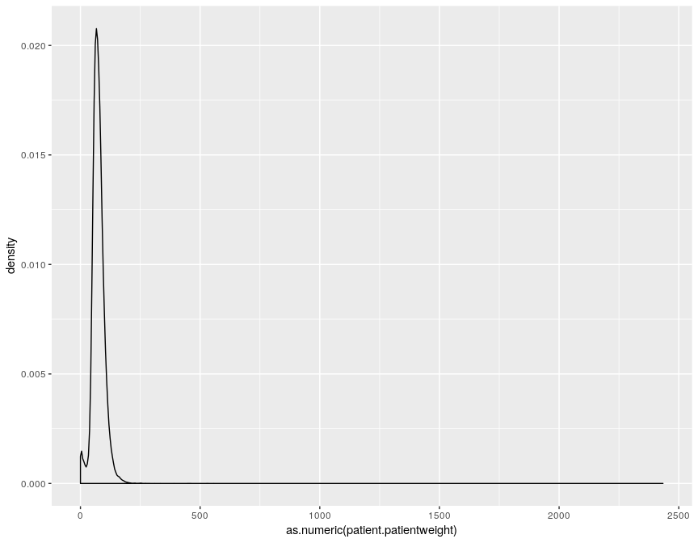

#### Adverse Events and Occuring countries

- Let’s attempt to answer if different adverse events are reported in different countries?
- Adverse Events definition is available here:https://www.fda.gov/safety/reporting-serious-problems-fda/what-serious-adverse-event
- 1 = The adverse event resulted in death, a life threatening condition, hospitalization, disability, congenital anomaly, or other serious condition
- 2 = The adverse event did not result in any of the above

```
##
##      1      2
## 218529 186744
```

- Number of distinct countries where events occured: 169

```
##
##     US     CA     FR     JP     GB     DE     IT     CN     ES     BR
## 274084  22571  15843  13631  12840  12216   7273   4621   4499   3432
##     AU     CO     NL     SE     PL     PT     AR     BE     IN     TR
##   3132   2751   2143   1556   1509   1467   1308   1231   1226    960
##     GR     KR     TW     AT     CH     IL     CZ     RO     MX     IE
##    918    861    859    810    780    760    686    685    683    646
##     ZA     RU     DK     HU     FI     CL     PR     NO     SG     HR
##    619    616    584    415    377    365    347    342    335    315
##     EG     NZ     IR     PK     SK     LB     HK     TH     PH     BG
##    296    238    225    225    225    219    201    200    180    176
##     MY     SI     CR     SA     GT     PE     AE     ID     LT     VN
##    172    161    138    126    115    115    104     96     93     89
##     EC     BW     UA     DO     TN     NG     KW     PA     RS     UY
##     82     74     69     64     64     61     60     60     59     57
##     HN     KE     UG     OM     EE     DZ     MA     LV     NP     BY
##     54     52     52     49     48     37     36     33     27     26
##     MM     KZ     QA     CY   <NA>     JO     BD     IS     LU     LK
##     26     23     22     21     20     18     17     17     16     15
##     VE     GE     MW     CM     PY     UM     ZW     BA     BO     CU
##     15     14     14     11     11     11     11     10      8      8
##     ET     GH     IQ     KP     ME     MT     BH     JM     MK     UZ
##      8      8      8      8      8      8      7      7      7      7
##     AL     CI     ML     SV     TJ     NE     RW     SN     TT     BS
##      6      6      6      6      6      5      5      5      5      4
##     KY     SY     BJ     BM     BZ     CD     GA     MZ     NI     AD
##      4      4      3      3      3      3      3      3      3      2
##     AF     AX     AZ     BB     BN     FJ     GU     HT     KH     MO
##      2      2      2      2      2      2      2      2      2      2
##     NA     AM     BF     BI     CG     CX     DM     FO     GN     GP
##      2      1      1      1      1      1      1      1      1      1
##     IM     LR     LY     MC     MD     MG     MN     NC     PG     PN
##      1      1      1      1      1      1      1      1      1      1
##     PS     QZ     SD     SZ     TM     TZ     VU     WS     XK
##      1      1      1      1      1      1      1      1      1
```

- Top 20 occuring countries with names

```
##
##  United States         Canada         France          Japan United Kingdom
##         274084          22571          15843          13631          12840
##        Germany          Italy          China          Spain         Brazil
##          12216           7273           4621           4499           3432
##      Australia       Colombia    Netherlands         Sweden         Poland
##           3132           2751           2143           1556           1509
##       Portugal      Argentina        Belgium          India         Turkey
##           1467           1308           1231           1226            960
```

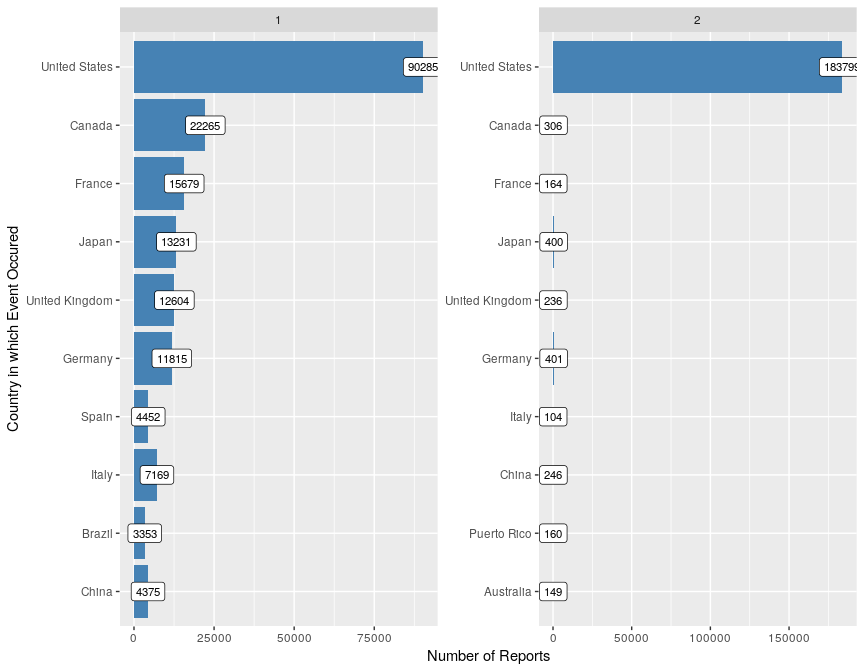

```
## # A tibble: 2 x 2
##   serious NumCountries
##   <chr>          <int>
## 1 1                165
## 2 2                 83

## # A tibble: 6 x 3
##   category                     NumReports FractionSerious1
##   <chr>                             <int> <chr>
## 1 seriousnessother                 147224 67.4%
## 2 seriousnesshospitalization        85639 39.2%
## 3 seriousnessdeath                  28067 12.8%
## 4 seriousnesslifethreatening        10374 4.7%
## 5 seriousnessdisabling               5197 2.4%
## 6 seriousnesscongenitalanomali       1643 0.8%
```

#### Adverse Reactions and Occuring countries

- What are different adverse reactions?
- Number of distinct adverse reactions: 11518
- Let’s get what are the top 10 adverse reactions

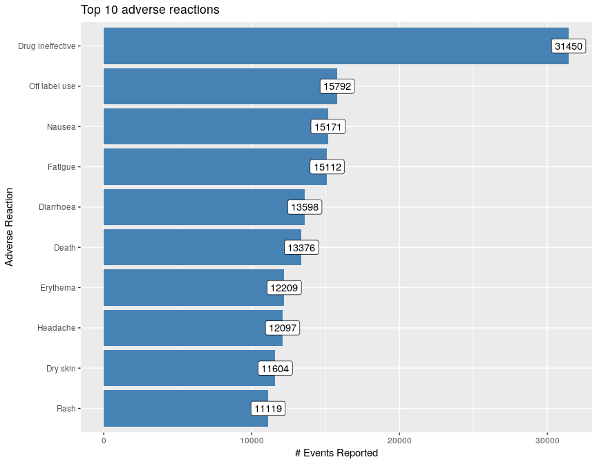

- What are the top 5 countries for each of the top 10 adverse reactions?

```
##     reactionmeddrapt           Name NumReports
##  1: Drug ineffective  United States      23574
##  2: Drug ineffective         Canada       4574
##  3: Drug ineffective United Kingdom        340
##  4: Drug ineffective          Italy        322
##  5: Drug ineffective        Germany        263
##  6:         Dry skin  United States      11270
##  7:         Dry skin         Canada        117
##  8:         Dry skin        Germany         32
##  9:         Dry skin United Kingdom         28
## 10:         Dry skin         Brazil         21
## 11:         Erythema  United States      10588
## 12:         Erythema         Canada        470
## 13:         Erythema         France        220
## 14:         Erythema        Germany        124
```

[output cut: 37 more lines]

- How many countries have these top 10 adverse reactions

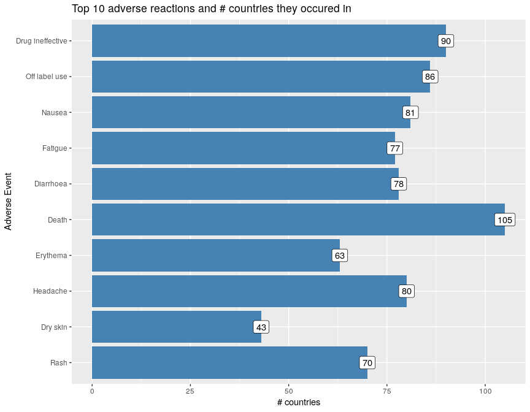

#### Adverse Events and disease areas

- What are different adverse events associated with different disease conditions?
- Disease areas can be identified from drugindication column within drug_df
- What are different disease areas?
- Number of distinct disease areas: 6131

```
##                       drugindication NumReports
##  1:                             ACNE      17382
##  2:             RHEUMATOID ARTHRITIS      15785
##  3:                     HYPERTENSION      11974
##  4:               MULTIPLE SCLEROSIS      11055
##  5:              PLASMA CELL MYELOMA      10949
##  6:                        PSORIASIS       9491
##  7: GASTROOESOPHAGEAL REFLUX DISEASE       7465
##  8:                             PAIN       7409
##  9:         TYPE 2 DIABETES MELLITUS       6284
## 10:            PSORIATIC ARTHROPATHY       5398
```

- What are adverse events within top 10 diseases

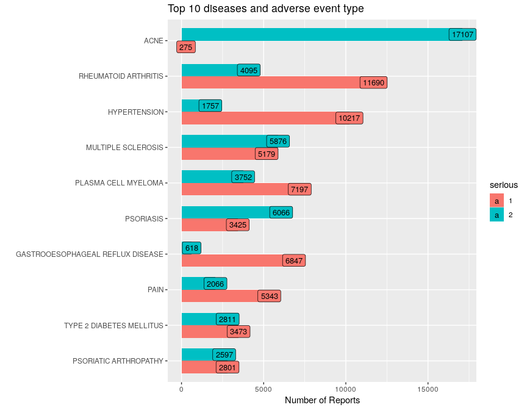

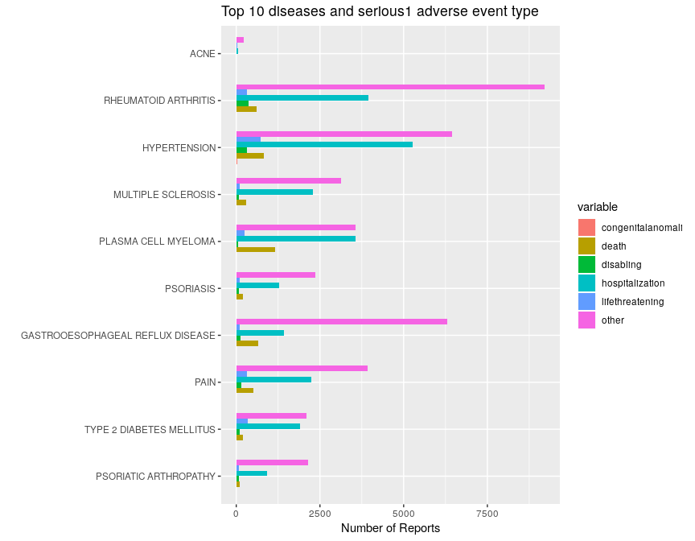

#### Drugs frequent itemsets

- What are the drugs frequently taken together
- activesubstancename is the drug info
- Number of distinct drugs: 5604
- Our objective is to find out what drugs are commonly taken together.
- We can use apriori algorithm from arules R package to identify frequent itemsets

```
## transactions as itemMatrix in sparse format with
##  405273 rows (elements/itemsets/transactions) and
##  5603 columns (items) and a density of 0.0005596283
##
## most frequent items:
##                           ADAPALENE                           COSMETICS
##                               36570                               32289
## AVOBENZONE\\OCTISALATE\\OCTOCRYLENE                             ASPIRIN
##                               31209                               15688
##                       ACETAMINOPHEN                             (Other)
##                               12404                             1142613
##
## element (itemset/transaction) length distribution:
## sizes
##      1      2      3      4      5      6      7      8      9     10
## 211873  44657  45304  28946  14550  10878   8400   6960   5832   4831
##     11     12     13     14     15     16     17     18     19     20
##   4284   3344   2839   2205   1833   1548   1215   1011    786    679
##     21     22     23     24     25     26     27     28     29     30
##    503    441    356    248    264    215    184    158    109    113
##     31     32     33     34     35     36     37     38     39     40
##     93     87     59     52     52     41     37     30     33     23
##     41     42     43     44     45     46     47     48     49     50
##     23     23     19     12     11     12     11     10      6      3
##     51     52     53     54     55     56     57     59     60     61
##      6      6      7      6      5      3      5      4      5      4
##     62     64     65     66     67     69     71     72     75     76
##      1      1      1      2      1      1      1      3      1      3
##     77     82    155
##      2      1      1
##
##    Min. 1st Qu.  Median    Mean 3rd Qu.    Max.
##   1.000   1.000   1.000   3.136   4.000 155.000
##
## includes extended item information - examples:
##                        labels
## 1             .ALPHA.-ASARONE
## 2 .ALPHA.-GLUCOSE-1-PHOSPHATE
## 3         .ALPHA.-LIPOIC ACID
```

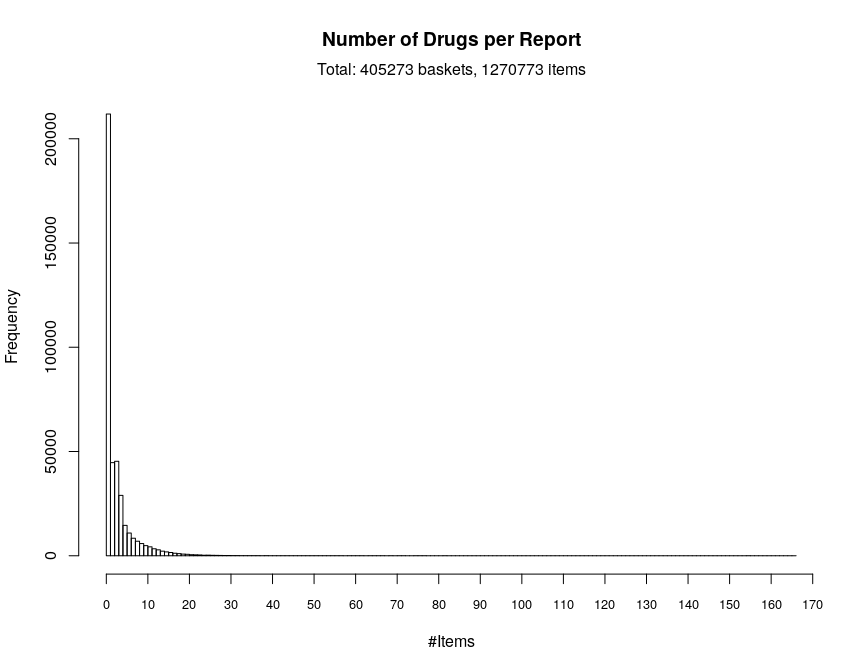

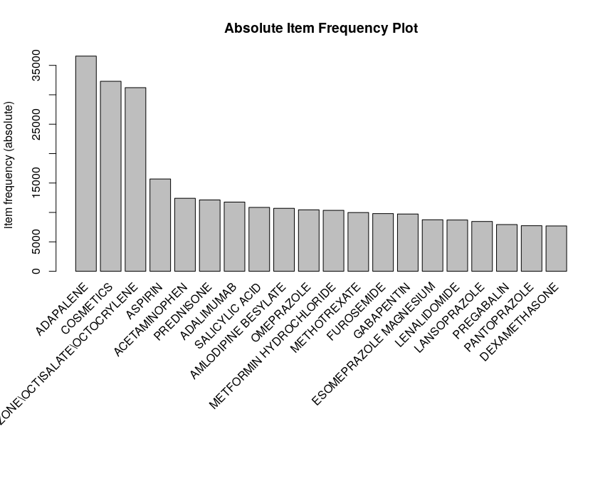

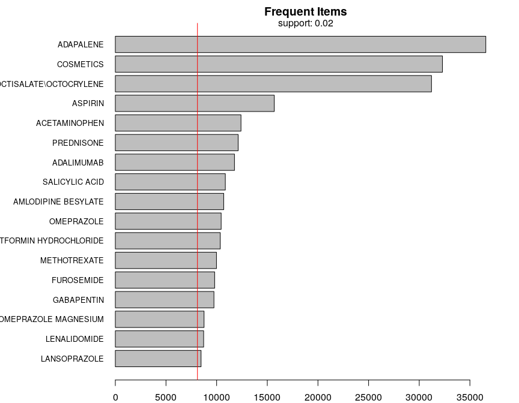

```
##      items                                                support
## [1]  {AVOBENZONE\\OCTISALATE\\OCTOCRYLENE,SALICYLIC ACID} 0.025528471
## [2]  {COSMETICS,SALICYLIC ACID}                           0.026364944
## [3]  {ADAPALENE,SALICYLIC ACID}                           0.026693118
## [4]  {OMEPRAZOLE MAGNESIUM,PANTOPRAZOLE SODIUM}           0.008073570
## [5]  {LANSOPRAZOLE,OMEPRAZOLE MAGNESIUM}                  0.010045081
## [6]  {ESOMEPRAZOLE MAGNESIUM,OMEPRAZOLE MAGNESIUM}        0.010888956
## [7]  {ESOMEPRAZOLE MAGNESIUM,PANTOPRAZOLE SODIUM}         0.008436289
## [8]  {ESOMEPRAZOLE MAGNESIUM,LANSOPRAZOLE}                0.011199858
## [9]  {AVOBENZONE\\OCTISALATE\\OCTOCRYLENE,COSMETICS}      0.076133865
## [10] {ADAPALENE,AVOBENZONE\\OCTISALATE\\OCTOCRYLENE}      0.076997481
##      count
## [1]  10346
## [2]  10685
## [3]  10818
## [4]   3272
## [5]   4071
## [6]   4413
## [7]   3419
## [8]   4539
## [9]  30855
## [10] 31205
```

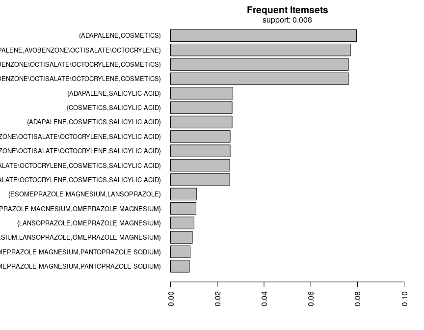

```
##                                                                       items
## 1                                                     {ADAPALENE,COSMETICS}
## 2                           {ADAPALENE,AVOBENZONE\\OCTISALATE\\OCTOCRYLENE}
## 3                           {AVOBENZONE\\OCTISALATE\\OCTOCRYLENE,COSMETICS}
## 4                 {ADAPALENE,AVOBENZONE\\OCTISALATE\\OCTOCRYLENE,COSMETICS}
## 5                                                {ADAPALENE,SALICYLIC ACID}
## 6                                                {COSMETICS,SALICYLIC ACID}
## 7                                      {ADAPALENE,COSMETICS,SALICYLIC ACID}
## 8                      {AVOBENZONE\\OCTISALATE\\OCTOCRYLENE,SALICYLIC ACID}
## 9            {ADAPALENE,AVOBENZONE\\OCTISALATE\\OCTOCRYLENE,SALICYLIC ACID}
## 10           {AVOBENZONE\\OCTISALATE\\OCTOCRYLENE,COSMETICS,SALICYLIC ACID}
## 11 {ADAPALENE,AVOBENZONE\\OCTISALATE\\OCTOCRYLENE,COSMETICS,SALICYLIC ACID}
## 12                                    {ESOMEPRAZOLE MAGNESIUM,LANSOPRAZOLE}
## 13                            {ESOMEPRAZOLE MAGNESIUM,OMEPRAZOLE MAGNESIUM}
## 14                                      {LANSOPRAZOLE,OMEPRAZOLE MAGNESIUM}
```

[output cut: 68 more lines]